# GainDrifts_02252019

```python
import pylab as pl
from  numpy.random import normal
import numpy as np
import healpy as hp
from scipy.signal import periodogram

from pylab import cm
cmap = cm.get_cmap('RdYlBu')
cmap.set_under('w')
```

```python
from IPython.display import HTML

HTML('''<script>
code_show=true;
function code_toggle() {
 if (code_show){
 $('div.input').hide();
 } else {
 $('div.input').show();
 }
 code_show = !code_show
}
$( document ).ready(code_toggle);
</script>
<form action="javascript:code_toggle()"><input type="submit" value="Click here to toggle on/off the raw code."></form>''')
```

## Gain Drifts with Monopole

We assume just a 1/f dependence for gain drifts with fk =150 mHz

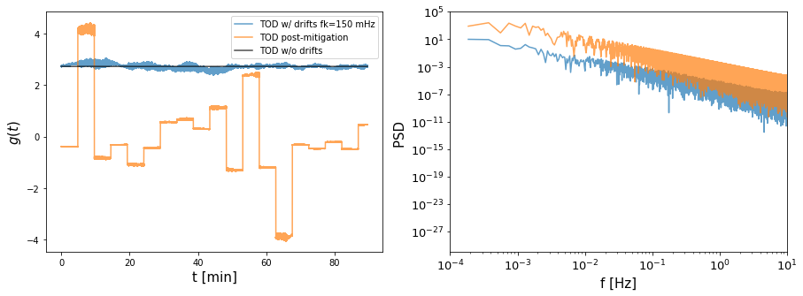

```python
wmitig2= pl.load('/Users/peppe/work/satellite_sims/drifting_gain/monopole/corr/outtod_mitig.npy')
wdrifts= pl.load('/Users/peppe/work/satellite_sims/drifting_gain/monopole/corr/outtod_drifts2.npy')
wmitig= pl.load('/Users/peppe/work/satellite_sims/drifting_gain/monopole/corr/outtod_mitig2.npy')
N=len(wmitig)
fs=40.
freq, spectrum= periodogram(wdrifts,fs=fs, scaling='density')
freq, spectrum2= periodogram(wmitig,fs=fs, scaling='density')
pl.figure(figsize=(15,5) )
pl.subplot(121)


t=pl.arange(N)/ fs/60
pl.plot(t, wdrifts , alpha=.7, label='TOD w/ drifts fk=150 mHz')
pl.plot(t, wmitig , alpha=.7, label='TOD post-mitigation')
pl.plot(t, wmitig2 , 'k', alpha=.7, label='TOD w/o drifts')
pl.xlabel('t [min]', fontsize=15)
pl.ylabel('$g(t)$ ', fontsize=15)
pl.legend()
pl.subplot(122)


pl.loglog(freq, spectrum, alpha=.7 )
pl.loglog(freq, spectrum2, alpha=.7 )

#pl.loglog(freq, [ PSDfunction(x, 0., fk, dnu )**2* 2* dnu  for x in freq ], lw=3 )
#pl.ylim([1e-12,1e1] )
pl.xlim([1e-4,1e1] )
pl.xticks(fontsize=13)
pl.yticks(fontsize=13)

pl.ylabel('PSD ', fontsize=15)
pl.xlabel('f [Hz]', fontsize=15)
```

**Caption** : TOD for 1 precession period, ( blue) gain drifts are not corrected , ( orange) gain drifts are mitigated by estimating the regression coefficient every 5 minutes (tried also 10 minutes and a similar plot comes out).

Similar residuals are observed with a lower fk (say 30 mHz)

### Post-mitigation maps

Input signal= Monopole, Dipole , CMB T

Maps have been destriped with Madam (baseline = 60 sec).

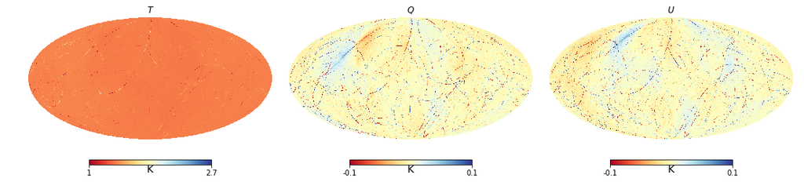

```python
driftmapdip= hp.read_map(field=range(3) ,
                       filename='/Users/peppe/work/satellite_sims/drifting_gain/monopole/corr/madam_map.fits',
                       verbose=False)
fig=pl.figure(figsize=(15,8))

hp.mollview(driftmapdip [0] , unit='K',title=r'$  T  $', sub=131  ,   min=1, max=2.7,fig=fig ,cmap=cmap   )
hp.mollview(driftmapdip [1] , unit='K',title=r'$  Q  $', sub=132  , min=-.1,max=0.1,fig=fig ,cmap=cmap   )
hp.mollview(driftmapdip [2] ,unit='K', title=r'$  U   $', sub=133 , min=-.1,max=0.1, fig=fig ,cmap=cmap      )
```

I think i've figured out why the regression in this case doesn't work. The reason is due to the fact that within the 5 minutes we regress the TOD of detB (which encodes a monopole + drift signal) against the template which is just a constant signal (around 2.7 K) . The mitigation therefore tries to fit for the extra fluctuation due to the drift and as a net result the estimation is biased . These 5 minutes bieases produce an overall effect into maps , who present stripes features together with larger residual after mitigation.

#### To does :

- Can perform a run with fk= 30 mHz , and regress on a similar time scale (say 60- 30 sec ) , not sure whether too much computational expensive
- Find a different methodology to mitigate..

As a sanity check, I've simplified the gain drift problem, just injecting the gain drifts as a constant fluctation every 10 min (as I 've done previously) on the very same input signal maps and regressing with the very same template.

As expected, the mitigation works perfectly . The oscillation observed every 10 min is due to the spinperiod scanning the dipole signal, (~1000 times smaller than monopole)

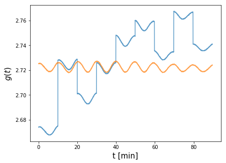

```python
wdrifts= pl.load('/Users/peppe/work/satellite_sims/drifting_gain/monopole/corr/outtod_drifts.npy')
wmitig2= pl.load('/Users/peppe/work/satellite_sims/drifting_gain/monopole/corr/outtod_mitig.npy')
N=len(wmitig)
fs=40.
pl.figure(figsize=(15,5) )
t=pl.arange(N)/ fs/60
pl.subplot(121)
pl.plot(t, wdrifts , alpha=.7)
pl.plot(t, wmitig2 , alpha=.7)

pl.xlabel('t [min]', fontsize=15)
pl.ylabel('$g(t)$ ', fontsize=15)
```

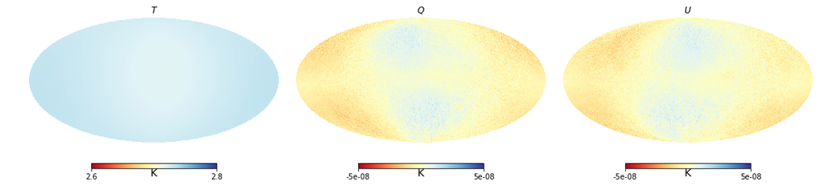

```python
driftmapdip= hp.read_map(field=range(3) ,
                       filename='/Users/peppe/work/satellite_sims/drifting_gain/monopole/corr/madam_map_001.fits',
                       verbose=False)
fig=pl.figure(figsize=(15,8))

hp.mollview(driftmapdip [0] , unit='K',title=r'$  T  $', sub=131  ,   min=2.6, max=2.8,fig=fig ,cmap=cmap   )
hp.mollview(driftmapdip [1] , unit='K',title=r'$  Q  $', sub=132  , min=-5e-8,max=5e-8,fig=fig ,cmap=cmap   )
hp.mollview(driftmapdip [2] ,unit='K', title=r'$  U   $', sub=133 , min=-5e-8,max=5e-8, fig=fig ,cmap=cmap      )
```